# Comparison of Local Regression in different R packages

Issam Arabi, Eric Maeder

2022-12-20

## Introduction

When applying statistical methods in R using built-in functions, it is common to be faced with multiple possible functions and packages aiming to tackle the same issues. In this scenario, and especially when dealing with large amounts of data, it is crucial yet difficult to choose the better-optimized one for fulfilling one’s goals. Optimization here denotes performance in terms of results precision and computation time.

In this context, we aim to explore the different R packages aiming to implement local polynomial interpolation and their performance by applying the packages and timing their execution on varied data sets of different sizes and structures to thoroughly assess their versatility.

## Plan

In this report, we will be following the method of analysis from the work of Deng and Wickham (2011) on density estimation. Effectively, we will start with a small introduction to local polynomial regression, followed by a description of the different R packages we will examine. Next, we will add the computation time of the different functions when applied to data sets of increasing sizes. Then, we will measure the performance of the considered functions when dealing with data sets with more challenging structures. Afterward, we will discuss the results, and lastly, we will summarize our results and conclude.

## Local Polynomial Regression

Local Polynomial regression, most widely known through the Locally Estimated Scatter-plot Smoothing (LOESS) method, is a powerful prediction tool when observing bounded data sets with non-trivial distributions. It is a non-parametric method, which allows it to be versatile and easy to use.

When observing response values $Y_1, Y_2, ...$ at points $X_1, X_2, ...$, local polynomial regression aims to assign at each point X the value corresponding to $\underset{\beta \in \mathbb{R}^{p+1}}{argmin} \sum_{i=1}^n [Y_i - \beta_0 - \beta_1(X_i - x) - ... - \beta_p (X_i - x)^p]^2 K(\frac{X_i - x}{h})$, where p is the order of the fitted polynomial, K is a kernel function (basically a weighting function), and h is a bandwidth parameter allowing to choose how strong the influence of distant observations on the regression should be.  
As we can see, this is a least squares problem, and although the solution is long and unexciting to produce, it comes down to computing a gradient and solving a relatively simple system of equations.

Then, the resulting polynomials are combined and smoothed to obtain a curve spanning the whole considered region. In practice, polynomial degrees p < 5 are mostly used due to the increasing computational challenge, which is the approach we will adopt in this report.

## Local Polynomial Regression Packages

In this section, we give a quick overview of the considered functions and their parameters.

- **stats::loess**, R Core Team (2022), from its documentation, fits a local polynomial surface determined by one or more numerical predictors, using local fitting. its typical call is as follows:

loess(formula, data, weights, subset, na.action, model = FALSE,  
span = 0.75, enp.target, degree = 2,  
parametric = FALSE, drop.square = FALSE, normalize = TRUE,  
family = c(“gaussian,” “symmetric”),  
method = c(“loess,” “model.frame”),  
control = loess.control(…), …)

But in our case, we will be working on fully-specified data sets with no missing data and no prior information about value importance, so we will only use the following:

loess(formula, (data),  
span = 0.75, degree = 2,  
family = “gaussian”  
method = “loess”)

where *formula* is where we set the response and explanatory variables, *span* is used to control the bandwidth, *degree* is self-explanatory and *family* specifies that we want a least-squares approach. *Span* works as follows: when given a value smaller than 1, each local regression is fitted using the proportion of observations equal to the span value into account, with tri-cubic weighting $(1 - (\frac{\text{distance to point}}{\text{maximal distance to considered points}})^3)^3$.

This approach prevents cases of badly spread data where no observation is in the considered bandwidth when fitting a local regression, making it unstable, at the cost of computing the distance to each data point. Moreover, this makes it difficult to compare to other functions, as we cannot give them the exact same inputs.

- **locpol::locpol**, Ojeda Cabrera (2022), follows the steps of the local polynomial regression described in the previous section. Its call is as follows:

locpol(formula,data,weig=rep(1,nrow(data)),bw=NULL,kernel=EpaK,deg=1,  
xeval=NULL,xevalLen=100)

again, we will not use all parameters for comparison in this report, although they offer room for versatility. Therefore, we will mostly use:

locpol(formula,(data),bw=NULL,kernel=EpaK,deg=1)

where *formula*, *data*, and *deg* are identical to the corresponding parameters in the loess function. The *bw* parameter is the bandwidth, and *kernel* is the kernel function set to Epanechnikov by default, but can be gaussian, uniform, etc. This follows closely the theoretical approach we chose.

- **KernSmooth::locpoly**, Wand (2021), aims to fit a local polynomial with kernel weighting to estimate a regression function. It can also be used for density estimation and its derivatives. We call it as follows:

locpoly(x, y, drv = 0L, degree, kernel = “normal,”  
bandwidth, gridsize = 401L, bwdisc = 25,  
range.x, binned = FALSE, truncate = TRUE)

Here, *x* and *y* are the explanatory and response variables, *drv* concerns derivative estimations, *kernel* and *bandwidth* are self-explanatory, *gridsize* represents the number of equidistant points over which we want to estimate the fct, and the last parameters are used to speed up computations when the data is pre-processed. This approach is pretty similar to locpol and consequently to our theoretical version. The similarity in input parameters makes it easy to compare both of them.

- **fANCOVA::loess.as**, Wang (2020), performs local polynomial regression with automatic bandwidth selection using either cross-validation or AIC as the criterion. It also gives the option to select it manually, which we will use for comparison. This is the usage:

loess.as(x, y, degree = 1, criterion = c(“aicc,” “gcv”),  
family = c(“gaussian,” “symmetric”), user.span = NULL,  
plot = FALSE, …)

where *x*, *y*, *degree*, and *criterion* are self-explanatory. Here we will use the Gaussian family corresponding to the Least Squares approach, and *user.span* is a manual smoothing parameter selection (bandwidth value e.g.). *plot* is an option to generate a visualization of the results.

#### Other more specific local regressions

- **caret::knnreg**, Kuhn (2022), and other k-nearest neighbors approaches, are a substitute to the bandwidth approach, making sure that isolates and outliers on the x-axis do not have too much impact on the results by always taking at least k observations into account.
- **spgwr::gwr**, Bivand and Yu (2022), performs a geographically weighted regression; a special type of local regression applicable to spatially ordered data, taking into account the distance of each observation when fitting a local estimate.

## Comparison of Computation times

To compare computation times for the functions, we run each of them for 1000 times and compare the average runtime. Below are the results.

```
## # A tibble: 1 × 4
##   loess            locpol          loess.as         locpoly
##   <drtn>           <drtn>          <drtn>           <drtn>
## 1 0.003000508 secs 0.01815013 secs 0.001230139 mins 0.0004496508 secs
```

From this data, we can see that loess.as takes much more time than the rest of the functions, followed by locpol, then loess. The most computationally efficient function was locpoly. This is due to the loess.as function calculating its optimal bandwidth internally, requiring the application of a selection algorithm, such as cross validation, or more generally a K-folds approach, for example. This does require extra time, but has the advantage of combining choosing an efficient span parameter and applying it at once. A more valid comparison would be to time a K-folds approach on the datasets to choose either a bandwidth or a span parameter, and add its execution time to the other functions.

## Comparison of approximation residuals

Now, we delve into the comparison of the fit produced by the different functions, applied to the same datasets. To do so, we use two families of different data sets: one stemming from the Gaussian distribution added to a sinusoidal factor, and one originating from the claw distribution noised Nason (2022). For both families, we look at samples of size $10^2,10^3,10^4$ and $10^5$. On each of those, we apply the four considered functions and we calculate the $R^2$ value, representing the goodness of fit (coefficient of determination). This allows for comparison between different functions on the same data sets and for the same function on different sizes of data sets.  
Worth keeping in mind is that two of the functions take a span parameter into account, denoting a percentage of the data points to consider, and the two others a bandwidth parameter. This implies the first two will not be meaningfully comparable to the latter, as we do not run any algorithm, such as cross-validation, to choose a bandwidth parameter. For the span parameter, since such an algorithm is already implemented in the loess.as function, we run the loess function with the resulting parameter to have comparatively similar performances.  
Since locpol function is inapplicable to datasets too large, we set the resulting R2 to 0 on the last plot.  
We output the different fit functions, tables of the $R^2$ coefficients, and lastly a plot of the coefficients of determination on each dataset size.

Let us start with the smaller datasets:

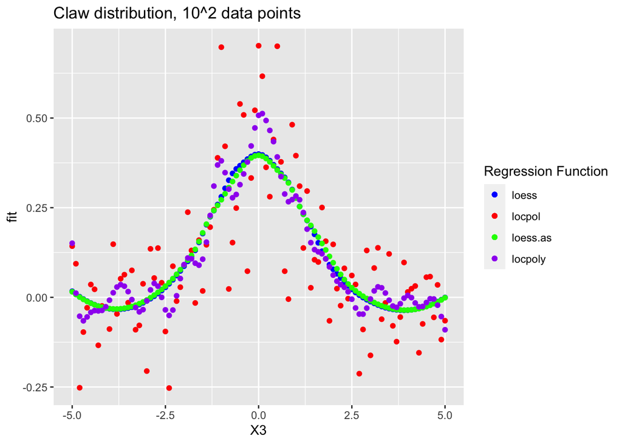

For now, we cannot see the claws emerging from the distribution, but that is only due to the inaccuracy induced by the small sample size, as the locpol function produces an R^2 of 1, meaning it approximates the function perfectly. The others underfit a bit, leading to smaller values and worse approximation. However, that might not be a bad result, as we are a priori with little data and therefore not sure whether we should fit the data so precisely as we fear overfitting to the data.

Let us look at what changes when we consider a superior order of magnitude:

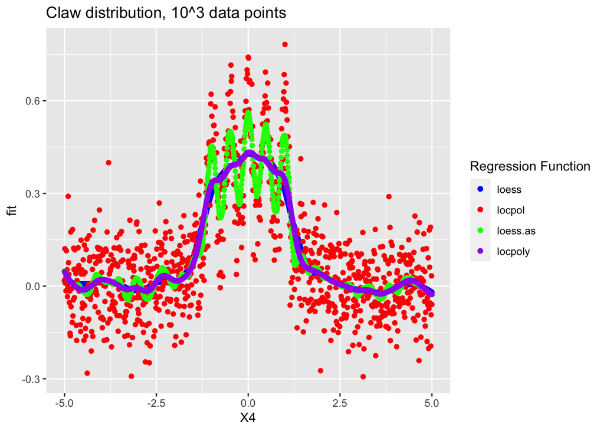

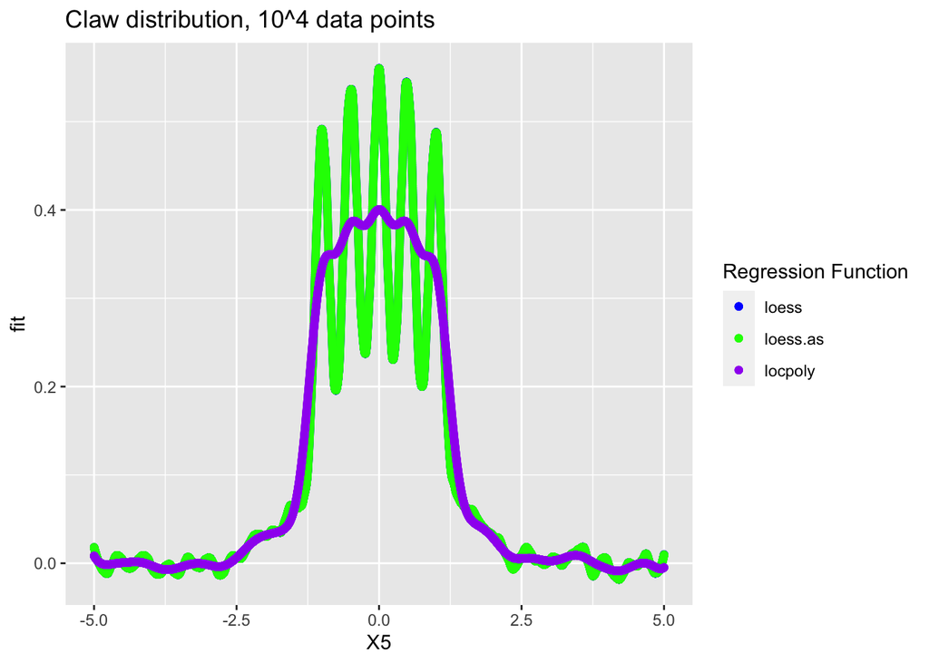

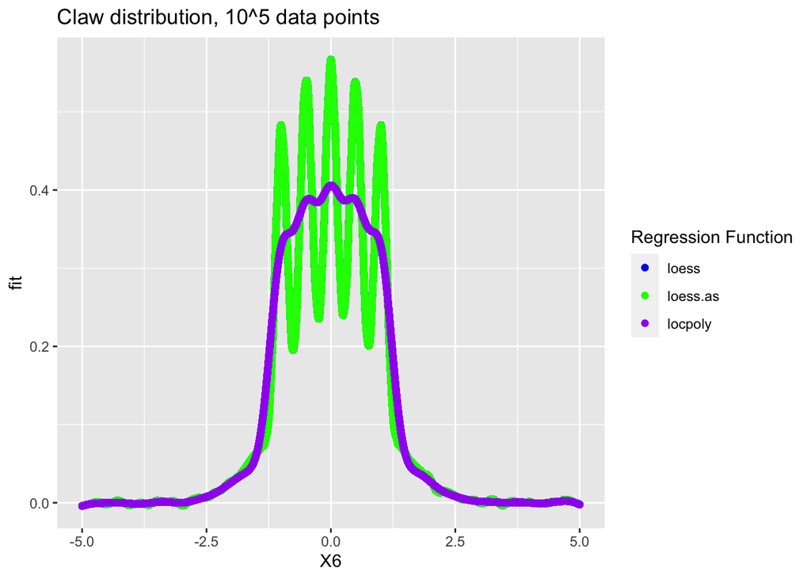

On the above two plots, we see loess and loess.as have shaped the target claw function quite nicely, which is appropriate, as we noised the data using a mean zero Gaussian function. Toward comprehension, let us have a look at the given dataset for the last computations (size $10^5$):

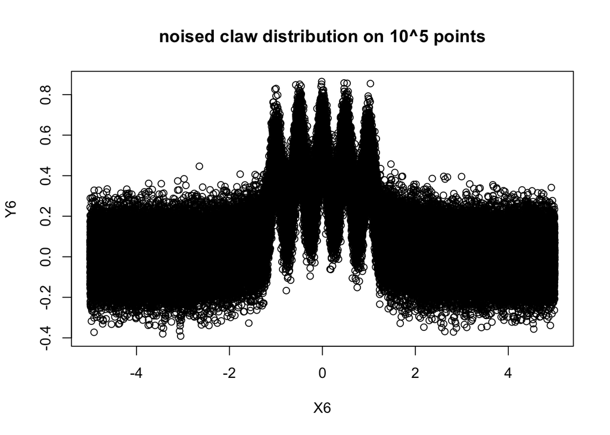

Now, let us look at the $R^2$ coefficients across the dataset sizes under the form of a table and a plot:

```
##      Loess             locpol loess.as          locpoly
## 10^2 0.573020880630545 1      0.572188864581951 0.684659859213335
## 10^3 0.631386385027604 1      0.739332678036681 0.648096092972678
## 10^4 0.728437097451768 -      0.728384801165796 0.630596676878575
## 10^5 0.727193052986165 -      0.727179450676932 0.631462964302566
```

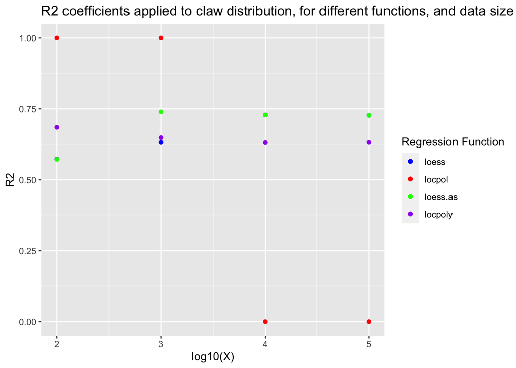

First looking at the table, we see loess and loess.as work similarly given the same parameters, meaning we can exchange one for the other, results-wise, depending on whether we know the span we want to use or not. Of course, computing this parameter takes time. Cross-validation has an $O(n^2)$ complexity, reduced to $O(Kn)$ when considering K-folds cross-validation, where n is the sample size. For the two bandwidth functions, locpol seems whenever applicable, a better choice compared to the locpoly, as it yields better results altogether. However, caution is needed when interpreting these results, as although a coefficient of determination equal to unity means the data is perfectly interpolated, it does not mean that the algorithm performs well when dealing with noised data, as that would indicate that the locpol function is over-fitting the data points. In this case, however, this is preferable, as it is the only function that shaped the existing claws when applied on datasets of small size.

Looking at the plot now, we see the loess and loess.as actually increase their coefficients of determination as the sample size grows. Indeed, it seems that it requires a lot of data to “convince” the loess.as algorithm to reduce its span parameter enough so that it does not underfit anymore. They obtain here better results than the locpoly function, but this entirely depends on the bandwidth parameter, that we would normally tune fine by applying an algorithm to choose it. As an example, we see the tendency to underfit disappears as expected when reducing the bandwidth, here by dividing it by 10:

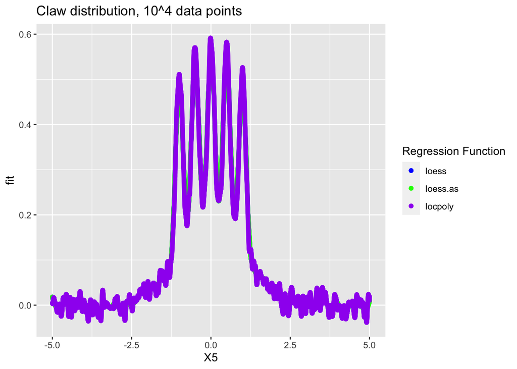

Now moving to a different family of data-sets, we generate this time a Gaussian random variable to which we add small sinusoidal components, aiming to generate softer waves than the claw function. Here, we expect the functions to perform better, as the local variations should be smoother. We also noise them identically to the claw data-set. This time, we use a smaller bandwidth for bigger data-sets for the locpoly function, as the previous one was clearly too big for the larger data-sets, as a higher x-axis density leads to more local samples and thus this reduction is relevant.

With this in mind, we now once again look at the different results, starting with order 100, and moving to 10^5.  
First, we look at the original curve we are trying to interpolate on $10^4$ points, without the noise:

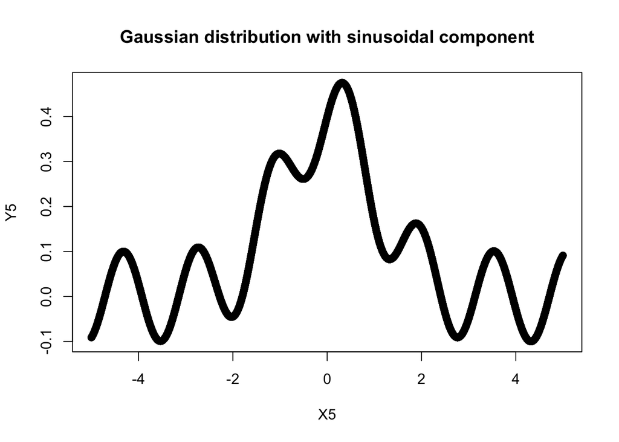

As we can see, the target is still wiggly, but the second derivative varies slower than in the previous example. Let us see how the different functions perform;

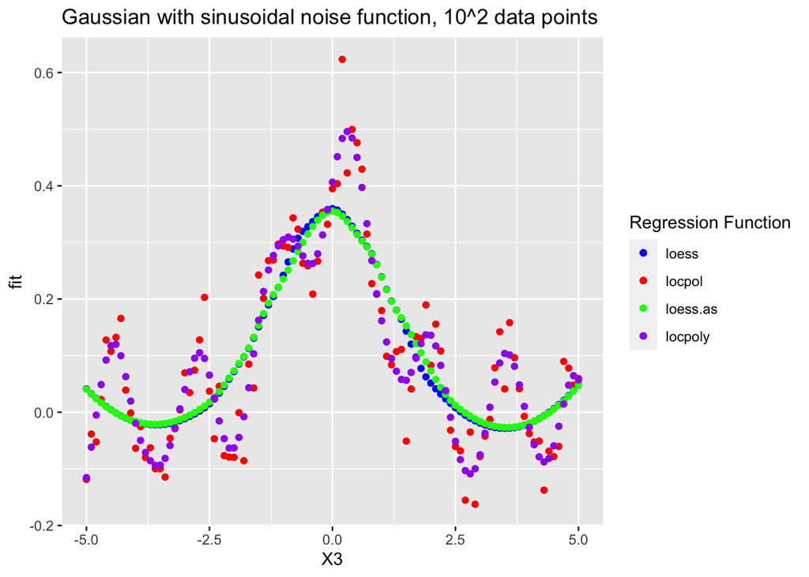

On the first graph, we can see that the span approaches under-fit the curve quite strongly, the locpoly function gives a good idea of the underlying curve, and the locpol function, while a bit too wiggly, also returns quality results. This is similar to what happened in the claw distribution case.

Let us observe the evolution of the regressions, as the number of data points increases:

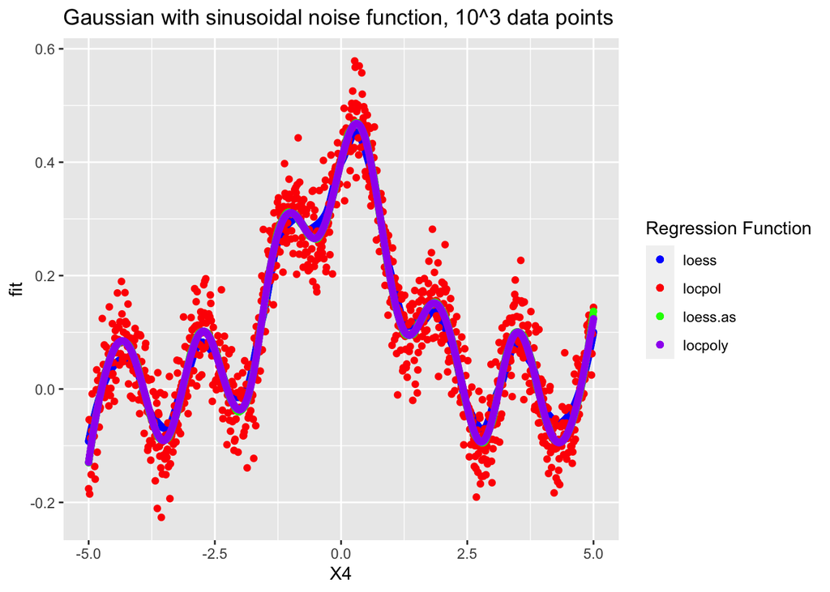

Here, we are still fitting the locpol and the locpoly functions with the same input parameters, but, once again, we notice a difference. It appears that the locpol function tends to over-fit quite badly in this case, which returns a noisy and rough resulting underlying curve, whereas the locpoly function and the two span approaches give a better result. Noticeable is the small under-fit of the loess function, possibly due to the approximation of the span parameter we input to it, instead of the exact number (order of $10^{-3}$).

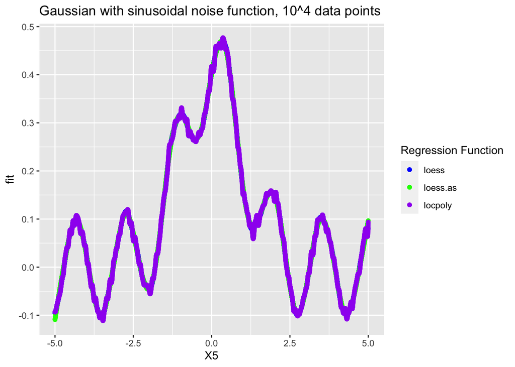

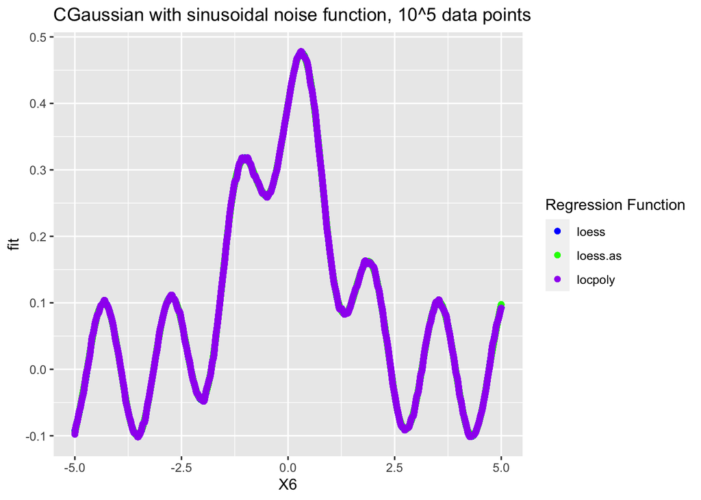

```
##      Loess             locpol loess.as          locpoly
## 10^2 0.677834859820614 1      0.67921529013187  0.939465183436603
## 10^3 0.891479290223784 1      0.909209423420533 0.90914412786956
## 10^4 0.902966041526938 -      0.902495079377217 0.905180719918072
## 10^5 0.902278980478461 -      0.902237521939386 0.902490201516509
```

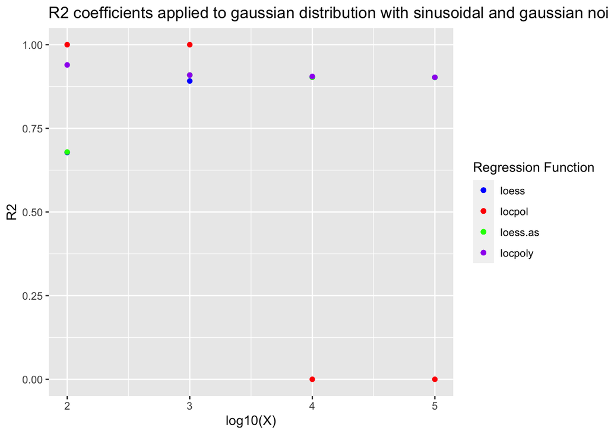

As we can see, when we increase the number of data points, the span and the bandwidth methods give similar results. For smaller samples, however, the bandwidth approach is preferable. Again, we can see a clear overfitting tendency from the locpol function, as both of the considered coefficients of determination are equal to one, meaning the algorithm interpolated each point perfectly, which might be detrimental when working with noised data.

A remaining concern is the difference in the results of the two functions taking a bandwidth as input parameter. Indeed, there is no explanation in the function descriptions that explain why they output results so differently, as both seem to ‘fit a local polynomial given a kernel and a bandwidth.’ A possibility would be the regression criteria, which could either be least squares, Aic, etc.

## General Results and Discussion

Based on the preceding parts, here are the main takeaways:

Overall, locpoly seems to be a good choice, both in terms of accuracy and time. However, we do need to select a bandwidth a priori. Loess and loess.as are very similar; thus, it all comes down to whether or not we think we have a good span parameter input or not. Locpol is somewhere at the same level of performance; it is slower than locpoly and does not apply to large datasets, but it gives interesting results and is a more sensitive function to local variations than locpoly.

## Conclusion

When only dealing with the application of local regression, the locpoly function from the Kernsmooth package is a great candidate, but the other ones are also decent candidates, due to their versatility (better performance for some specific inputs) and their results that are quite accurate in general.

To look further into the matter, one could explore the following ideas:

- Run a K-folds algorithm for choosing bandwidth/span externally, then compare the resulting run-time with loess.as’s (which computes it internally).
- Evaluate the performance of the different functions on datasets with a varying X-axis density. In our analysis, the data points were evenly distributed on the interval, but variations can have an impact, especially on the bandwidth approach.
- Check the code of the locpol and locpoly functions to examine why their results differ.
- Instead of the $R^2$ criteria, implement a similar version of the calculations but using the residuals from the regression values to the function before it was noised (i.e. the underlying curve) to assess the performance in a more formal way. Here, the resulting values would decrease as soon as the considered algorithm would start either to underfit, or to overfit, which would make for a relevant complementary criteria to assessing the resulting curve.

## References (add references to fcts and packages)

Bivand, Roger, and Danlin Yu. 2022. *Spgwr: Geographically Weighted Regression*. https://CRAN.R-project.org/package=spgwr.

Deng, Henry, and Hadley Wickham. 2011. “Density Estimation in r.” *Electronic Publication*.

Kuhn, Max. 2022. *Caret: Classification and Regression Training*. https://CRAN.R-project.org/package=caret.

Nason, Guy. 2022. *Wavethresh: Wavelets Statistics and Transforms*. https://CRAN.R-project.org/package=wavethresh.

Ojeda Cabrera, Jorge Luis. 2022. *Locpol: Kernel Local Polynomial Regression*. https://CRAN.R-project.org/package=locpol.

R Core Team. 2022. *R: A Language and Environment for Statistical Computing*. Vienna, Austria: R Foundation for Statistical Computing. https://www.R-project.org/.

Wand, Matt. 2021. *KernSmooth: Functions for Kernel Smoothing Supporting Wand & Jones (1995)*. https://CRAN.R-project.org/package=KernSmooth.

Wang, Xiaofeng. 2020. *fANCOVA: Nonparametric Analysis of Covariance*. https://CRAN.R-project.org/package=fANCOVA.